# Life-Income Analysis in States

Maksim Sannikov

03/07/2024

Loading the dataset:

```r
states = read.csv('states')
knitr::kable(head(states))
```

| X | Population | Income | Illiteracy | Life.Exp | Murder | HS.Grad | Frost | Area | state.name | state.region | states.region.abb |
| --- | --- | --- | --- | --- | --- | --- | --- | --- | --- | --- | --- |
| 1 | 3615 | 3624 | 2.1 | 69.05 | 15.1 | 41.3 | 20 | 50708 | alabama | South | S |
| 2 | 365 | 6315 | 1.5 | 69.31 | 11.3 | 66.7 | 152 | 566432 | alaska | West | W |
| 3 | 2212 | 4530 | 1.8 | 70.55 | 7.8 | 58.1 | 15 | 113417 | arizona | West | W |
| 4 | 2110 | 3378 | 1.9 | 70.66 | 10.1 | 39.9 | 65 | 51945 | arkansas | South | S |
| 5 | 21198 | 5114 | 1.1 | 71.71 | 10.3 | 62.6 | 20 | 156361 | california | West | W |
| 6 | 2541 | 4884 | 0.7 | 72.06 | 6.8 | 63.9 | 166 | 103766 | colorado | West | W |

Investigating the structure of the dataset:

```r
str(states)
```

```
## 'data.frame':    50 obs. of  12 variables:
##  $ X                : int  1 2 3 4 5 6 7 8 9 10 ...
##  $ Population       : int  3615 365 2212 2110 21198 2541 3100 579 8277 4931 ...
##  $ Income           : int  3624 6315 4530 3378 5114 4884 5348 4809 4815 4091 ...
##  $ Illiteracy       : num  2.1 1.5 1.8 1.9 1.1 0.7 1.1 0.9 1.3 2 ...
##  $ Life.Exp         : num  69 69.3 70.5 70.7 71.7 ...
##  $ Murder           : num  15.1 11.3 7.8 10.1 10.3 6.8 3.1 6.2 10.7 13.9 ...
##  $ HS.Grad          : num  41.3 66.7 58.1 39.9 62.6 63.9 56 54.6 52.6 40.6 ...
##  $ Frost            : int  20 152 15 65 20 166 139 103 11 60 ...
##  $ Area             : int  50708 566432 113417 51945 156361 103766 4862 1982 54090 58073 ...
##  $ state.name       : chr  "alabama" "alaska" "arizona" "arkansas" ...
##  $ state.region     : chr  "South" "West" "West" "South" ...
##  $ states.region.abb: chr  " S" "W " "W " " S" ...
```

Providing summary statistics for the variables ‘murder’ and ‘state region’.

```r
summary(states$Murder)
```

```
##    Min. 1st Qu.  Median    Mean 3rd Qu.    Max.
##   1.400   4.350   6.850   7.378  10.675  15.100
```

```r
summary(as.factor(states$state.region))
```

```
## North Central     Northeast         South          West
##            12             9            16            13
```

Providing a mean murder rate for each state and calculating the total number of murders by creating a variable ‘total_murders’ which is the murder rate (rate per 100,000 population) of each state multiplied by 100,000 and summed up to get the number for each state region.

```r
library(dplyr)

tab1 = states %>%
  select(Murder, state.region) %>%
  group_by(state.region) %>%
  summarise(total_rate = mean(Murder), total_murders = sum(Murder * 100000))

knitr::kable(tab1)
```

| state.region | total_rate | total_murders |
| --- | --- | --- |
| North Central | 5.275000 | 6330000 |
| Northeast | 4.722222 | 4250000 |
| South | 10.581250 | 16930000 |
| West | 7.215385 | 9380000 |

Providing a mean income for each state and calculating the total income by creating a variable ‘total_income’ which represents the income per capita of each state multiplied by the population of each state and summed up to get the number for each state region.

```r
tab2 = states %>%
  select(Income, state.region, Population) %>%
  group_by(state.region) %>%
  summarise(mean_income = mean(Income), total_income = sum(Income*Population))

knitr::kable(tab2)
```

| state.region | mean_income | total_income |
| --- | --- | --- |
| North Central | 4611.083 | 269154800 |
| Northeast | 4570.222 | 237491085 |
| South | 4011.938 | 277449070 |
| West | 4702.615 | 185708796 |

Visualizing the distribution of the number of murders across the state regions and added means:

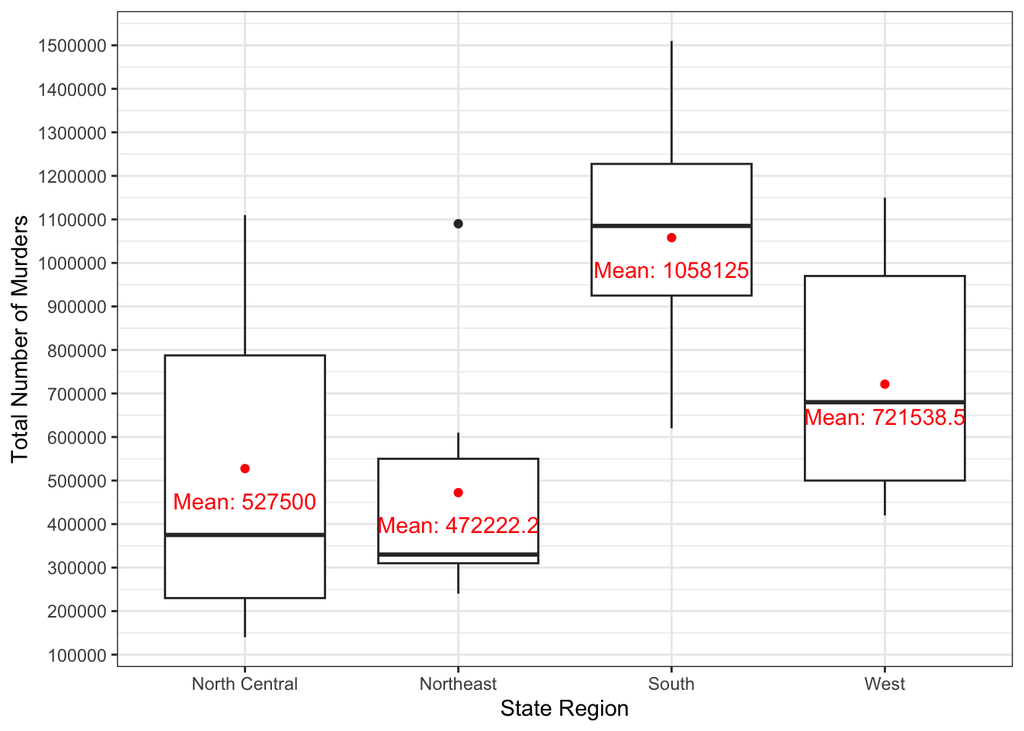

```r
library(ggplot2)

states$total_murders = states$Murder*100000

ggplot(data = states, aes(y = total_murders, x = state.region)) +
  geom_boxplot() +
  stat_summary(fun = mean, geom = "point", col = "red") +
  stat_summary(fun = mean, geom = "text", col = "red",
               vjust = 2.5, aes(label = paste("Mean:", round(..y.., digits = 1)))) +
  scale_y_continuous(breaks=seq(0,1500000,100000)) +
  labs(x = 'State Region', y = 'Total Number of Murders') +
  theme_bw() +
  theme(legend.position = "none")
```

From the graph, we can see that in South region there is the biggest concentration of murders (mean = 1,058,125), while in the Northeast region there is the lowest (mean = 472,222). The West (mean = 721,538) and North Central (527,500) regions showed the moderate level of murders. In the North Central region we have a wider distribution of total murders, 50% of data lies between approximately 200,000 and 800,000. The Northeast region has the most narrow distribution, 50% of data lies between 300,000 and 550,000. There is an outlier in the Northeast region which is New York which has an extremely high concentration of murders compared to the other states in the region.

Computing the average of Life Expectations for each state region using R base:

```r
means = sapply(unique(states$state.region),
       function(i) mean(states$Life.Exp[states$state.region == i], na.rm = TRUE))
means
```

```
##         South          West     Northeast North Central
##      69.70625      71.23462      71.26444      71.76667
```

Computing the standard deviations of Life Expectations for each state region using R base:

```r
sds = sapply(unique(states$state.region),
       function(i) sd(states$Life.Exp[states$state.region == i], na.rm = TRUE))
sds
```

```
##         South          West     Northeast North Central
##     1.0221994     1.3519715     0.7438769     1.0367285
```

Computing the average of Life Expectations for each state region using ‘dplyr’:

```r
states %>%
  group_by(state.region) %>%
  summarise(avg_life = mean(Life.Exp))
```

```
## # A tibble: 4 × 2
##   state.region  avg_life
##   <chr>            <dbl>
## 1 North Central     71.8
## 2 Northeast         71.3
## 3 South             69.7
## 4 West              71.2
```

Computing the standard deviations of Life Expectations for each state region using ‘dplyr’:

```r
states %>%
  group_by(state.region) %>%
  summarise(sd_life = sd(Life.Exp))
```

```
## # A tibble: 4 × 2
##   state.region  sd_life
##   <chr>           <dbl>
## 1 North Central   1.04
## 2 Northeast       0.744
## 3 South           1.02
## 4 West            1.35
```

Visualizing the Life Expectations for each state region and adding the means:

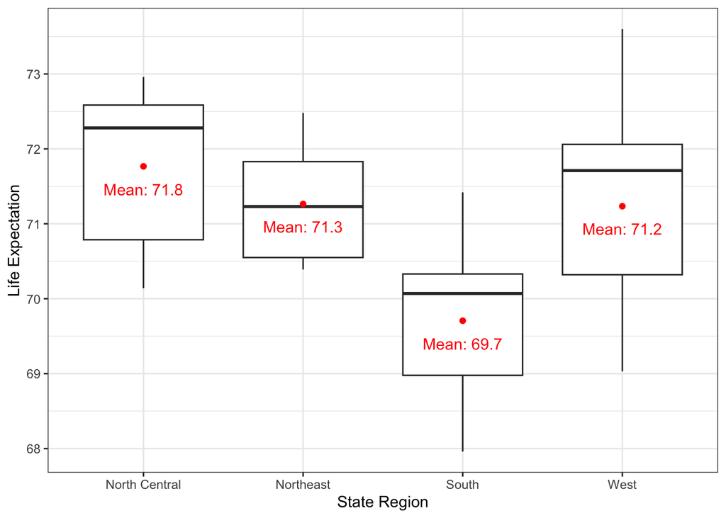

```r
ggplot(data = states, aes(y = Life.Exp, x = state.region)) +
  geom_boxplot() +
  stat_summary(fun = mean, geom = "point", col = "red") +
  stat_summary(fun = mean, geom = "text", col = "red",
               vjust = 2.5, aes(label = paste("Mean:", round(..y.., digits = 1)))) +
  labs(x = 'State Region', y = 'Life Expectation') +
  theme_bw() +
  scale_y_continuous(breaks=seq(65,75,1)) +
  theme(legend.position = "none")
```

From the graph, we can see that in North Central region has the highest Life Expectation (mean = 71.8), while the South region has the lowest (mean = 69.7). The West (mean = 71.2) and Northeast (71.3) regions showed the moderate level of Life Expectation.

Visualizing the relationship between Income and Life Expectation for each state region.

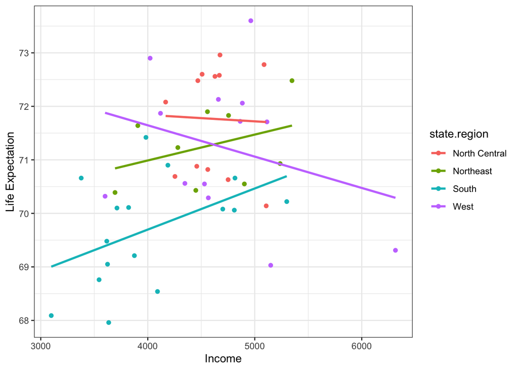

```r
ggplot(data = states, aes(x = Income, y = Life.Exp, col = state.region)) +
  geom_point() +
  geom_smooth(aes(x = Income, y = Life.Exp, col = state.region), method = 'lm', se = FALSE) +
  scale_y_continuous(breaks=seq(65,75,1)) +
  labs(y = "Life Expectation") +
  theme_bw()
```

In South and Northeast regions the relationship between Income and Life Expectation is positive which means the higher is the income the higher is Life Expectation. On the contrary, in West region the relationship is negative which means the higher is the Income the lower is the Life Expectation. In the North Central region there is almost no relationship between Income and Life Expectation.

First, loading the adjacency matrix ‘usaww’.

```r
library(splm)
data("usaww")
str(usaww)
```

```
##  num [1:48, 1:48] 0 0 0 0 0 0 0 0.5 0.2 0 ...
##  - attr(*, "dimnames")=List of 2
##   ..$ : chr [1:48] "ALABAMA" "ARIZONA" "ARKANSAS" "CALIFORNIA" ...
##   ..$ : chr [1:48] "ALABAMA" "ARIZONA" "ARKANSAS" "CALIFORNIA" ...
```

Secondly, deleting the rows with Alaska and Hawaii states.

```r
states_new = states %>%
  filter(state.name != 'alaska' & state.name != 'hawaii')
```

Thirdly, converting the adjacency matrix into 0-1 adjacency matrix. We set the minimum correlation to 0.3.

```r
adj = (abs(usaww) > 0.3)*1
```

Then, converting it into a network.

```r
library(network)

net = network(adj, directed = FALSE)
```

Finally, representing it through a network with nodes colors corresponding to state regions and node sizes corresponding to the total number of murders in each state.

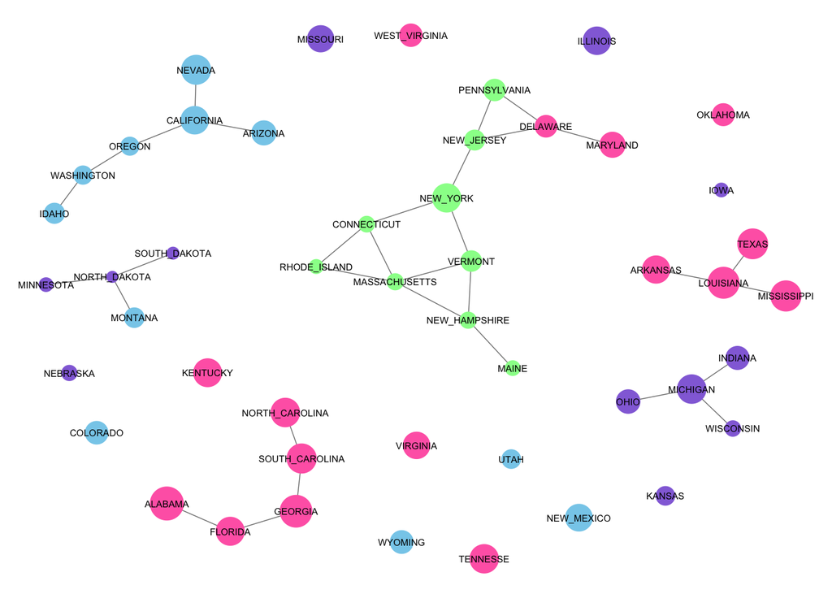

```r
library(sna)
library(GGally)

col <- states_new %>%
  mutate(region_color = case_when(
    state.region == "South" ~ "hotpink",
    state.region == "West" ~ "skyblue",
    state.region == "North Central" ~ "mediumpurple",
    state.region == "Northeast" ~ "palegreen",
    TRUE ~ "gray"
  )) %>%
  pull(region_color)

size <- states_new$total_murders

set.seed(1)
ggnet2(net, label = TRUE, label.size = 2,
       node.color = col, node.size = size) +
  theme(legend.position = "None")
```

As you can see from the network, there are several ‘clusters’ of states which are weakly connected (correlation > 0.3). There is a cluster of states from Northeast region (green), two clusters of states from South region (pink), one cluster of states from West region (blue) and two small clusters of states from North Central region (purple). Also, we can see that the nodes corresponding to the states from the South region (pink) are the biggest in size which matches what we’ve seen in the boxplots.

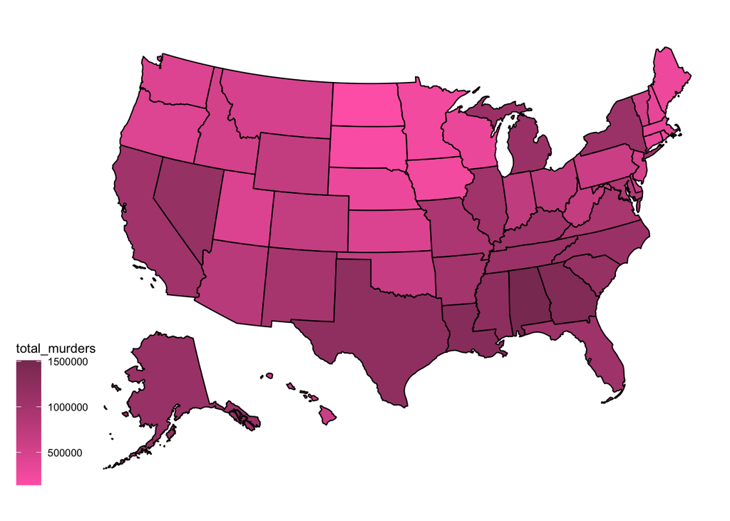

```r
library(usmap)

states['state'] = states['state.name']

plot_usmap(data = states, values = 'total_murders', regions = "states", ) +
  theme(panel.background=element_blank()) +
  scale_fill_continuous(low = "hotpink", high = "hotpink4")
```

The map shows that the South region has the biggest concentration of murders, while North part has lower concentration of murders.